# R 회귀분석

Jang, Eunhee

2018년 5월 31일

### 목차

1. 단순 선형회귀분석 이론
2. 단순 선형회귀분석 실습
- 탄닌 함유량과 애벌래 성장
- 우주 왕복선 챌린저 폭발 원인분석
- 코스피 지수 수익률과 삼성, 현대, 자동차 주식 수익율의 상관관계 분석
3. 다중 선형 회귀 분석 이론
4. 다중 선형 회귀 실습
- 스마트폰 만족도에 미치는 영향 분석
- 미국 대학 입학에 가장 영향이 높은 과목 분석
- 보혐회사의 보험료 인상에 미치는 요소분석

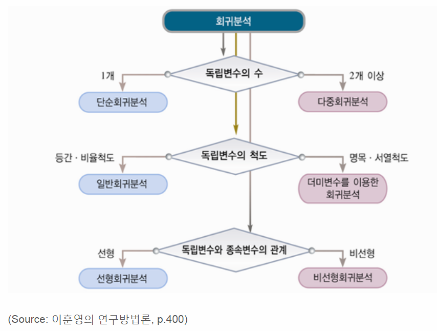

단순회귀 vs 다중회귀

### 1. 단순 선형회귀 분석 이론

#### 회귀란?

유전학자 프린시스 골턴이 유전의 법칙을 연구하다가 나온 명칭 아버지의 키가 크다고 할지라도 다들의 키는 아들세대의 평균으로 접근하는 경향이 있다는 것을 발견했다. -> 평균으로의 회귀

##### 쉽게 말하면?

1. 몸무게(독립변수)에 따라서, 키(종속변수)가 어떻게 되는가?

2. 담배판매량(독립변수)이 변하면, 폐암환자수(종속변수)가 어떻게 변하는가?
3. 공장의 기계(독립변수)를 바꾸면, 생산량(종속변수)은 어떻게 변하는가?

> 회귀는 독립변수와 종속변수 둘사이에 상관관계가 있다는 것에서 끝나는 것이 아니라 어떤 관계인지까지 자세히 살펴보는 것이다  
> 사회과학에서 특히 많이 쓰는 분석 방법

#### 회귀분석이란?

회귀분석은 하나의 변수가 나머지 다른 변수들과의 선형적 관계를 갖는가의 여부를 분석하는 방법  
하나의 종속변수(예측하고자하는 값) 와 독립변수 사이의 관계를 명시하는 것  
- 독립변수: 종속변수에 영향을 주는 변수  
예: 집가격에 영향을 주는 변수 ( 역세권, 지역상권, 학군, 평수)  
- 종속변수: 서로 관계를 가지고 있는 변수들 중에서 다른 변수에 영향을 받는 변수 예: 집가격에 영향

#### 회귀분석을 하기위한 전제조건 2가지

1. 종속변수값들이 정규분포에 해당되어야 한다.
2. 독립변수 값들이 여러개인 경우 독립변수들 간에 서로 영향을 주는 성향이 존재하지 않아야 한다.  
   (통계용어: 다중공선성)

#### 회귀직선을 도출하는 과정

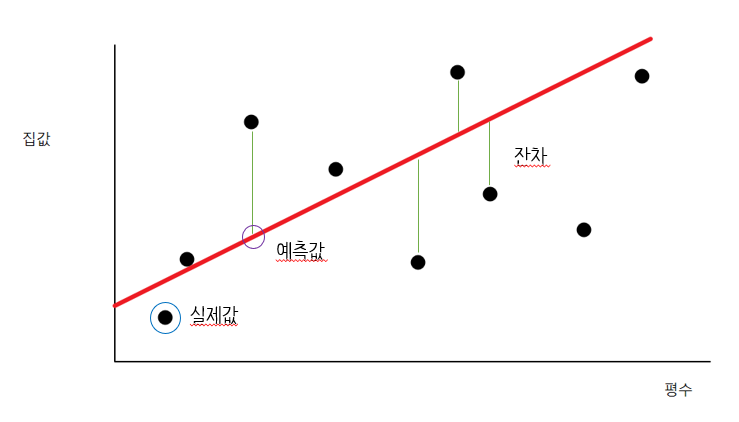

> y = ax + b (a, b: 회귀모수) 다시말해 y = ｗ１＊Ｘ＝ ＋ ｗ２  
> 잔차의 제곱의 합이 최소가 되도록 하는 최적의 직선식을 구하는 방법 = 최소 자승법

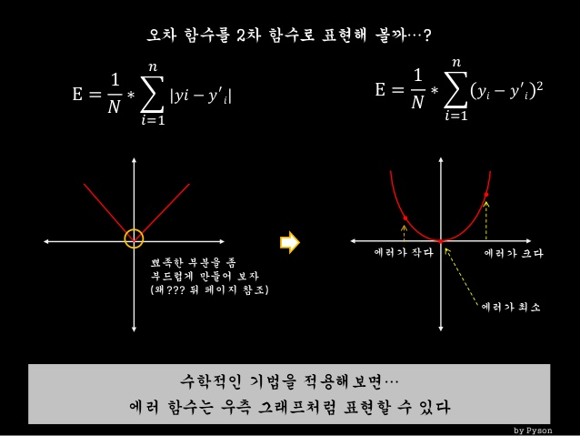

오차함수

### 단순 선형회귀분석 실습

data: 탄닌 함유량과 애벌래 성장

주제: “사료회사에서 필요한 회귀분석”

탄닌? 애벌래 몸에는 좋은데 맛이 없는 것

분석목표: 탄닌 함유 적당량 찾기 (by 회귀직선)

```r
rm()
# 1. 데이터를 R로 로드한다.
reg <- read.table("C:/data/regression.txt", header = T)

# 2. 데이터를 가지고 plot 그래프를 그린다.
#    (x축: 탄닌 함유량, y축: 애벌래 성장율)
attach(reg)

plot(growth~tannin, data = reg, col = "Hot Pink", bg = "red")

# 3. 데이터에 맞는 회귀모델을 만든다.
# install.packages("stats")
library(stats)

            # y 축 ~ x 축
model <- lm(growth~ tannin)
model
```

```
##
## Call:
## lm(formula = growth ~ tannin)
##
## Coefficients:
## (Intercept)       tannin
##      11.756       -1.217
```

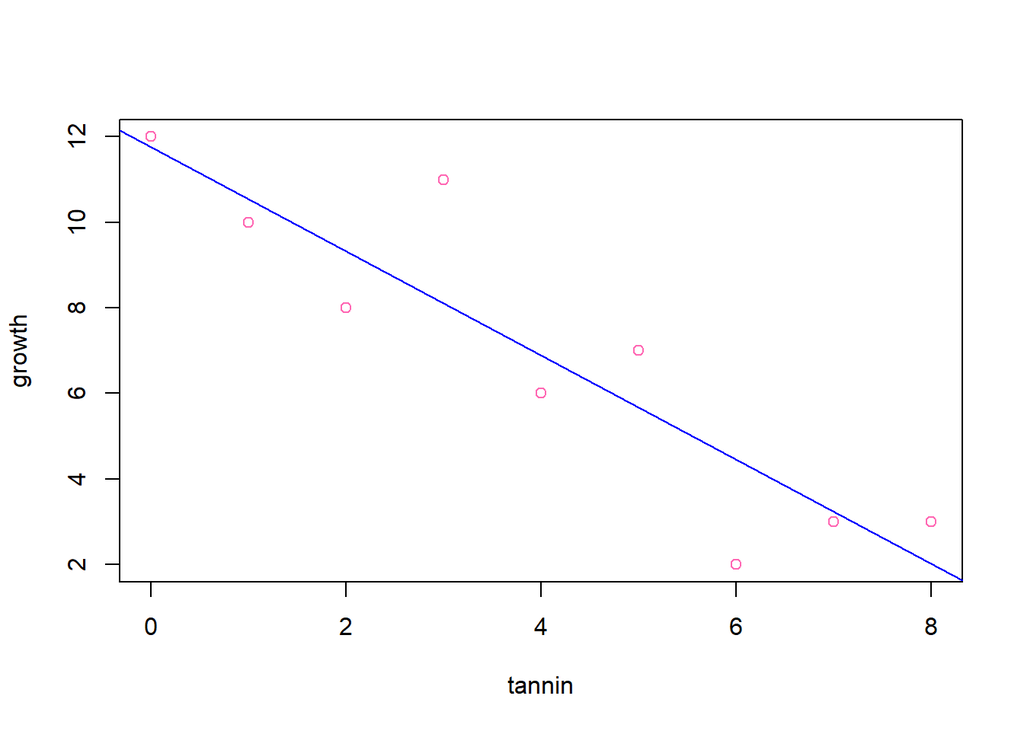

```r
# 절편        직선
# 11.756       -1.217

# 4. 회귀모델을 이용해 직선을 그린다.(단, plot그래프와 함께 그려야함)
# y = -1.217x + 11.756
abline(model, col = "blue")
```

#### 문제279. 탄닌 함유량이 200일때 애벌래 성장률은 어떻게 되는지 R로 구현하시오!

```r
y <- -1.217 * 200 + 11.756
y
```

```
## [1] -231.644
```

#### 문제280. 위의 plot 그래프를 출력할 때 제목으로 직선의 방정식 식이 출력되게 하시오

```r
# 1. 데이터를 R로 로드한다.
reg <- read.table("C:/data/regression.txt", header = T)

# 2. 데이터를 가지고 plot 그래프를 그린다.
#    (x축: 탄닌 함유량, y축: 애벌래 성장율)
attach(reg)
# 3. 데이터에 맞는 회귀모델을 만든다.
# install.packages("stats")
library(stats)

            # y 축 ~ x 축
model <- lm(growth~ tannin)
model
```

```
##
## Call:
## lm(formula = growth ~ tannin)
##
## Coefficients:
## (Intercept)       tannin
##      11.756       -1.217
```

```r
model$coefficients
```

```
## (Intercept)      tannin
##   11.755556   -1.216667
```

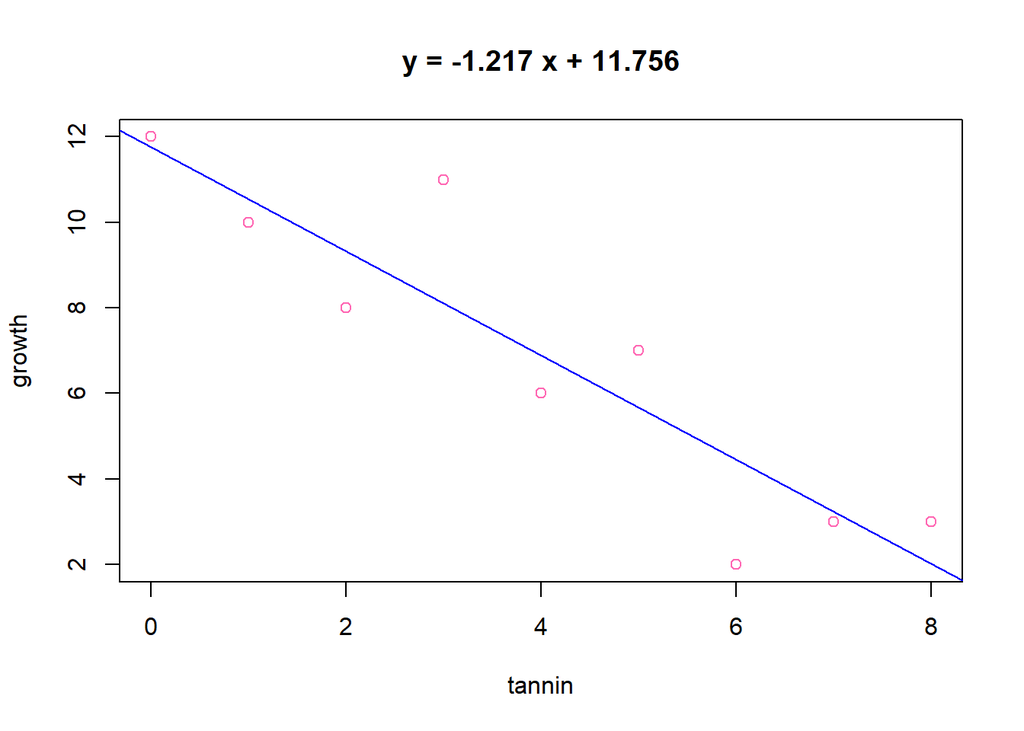

```r
plot(growth~tannin, data = reg, col = "Hot Pink", bg = "red", main = paste("y =", round(model$coefficients[2],3),"x +",round(model$coefficients[1],3)))
abline(model, col = "blue")
```

#### 문제281. 실습2

data: 챌린저호 폭파원인

```r
launch <- read.csv("C:/data/challenger.csv", header = T)

attach(launch)
```

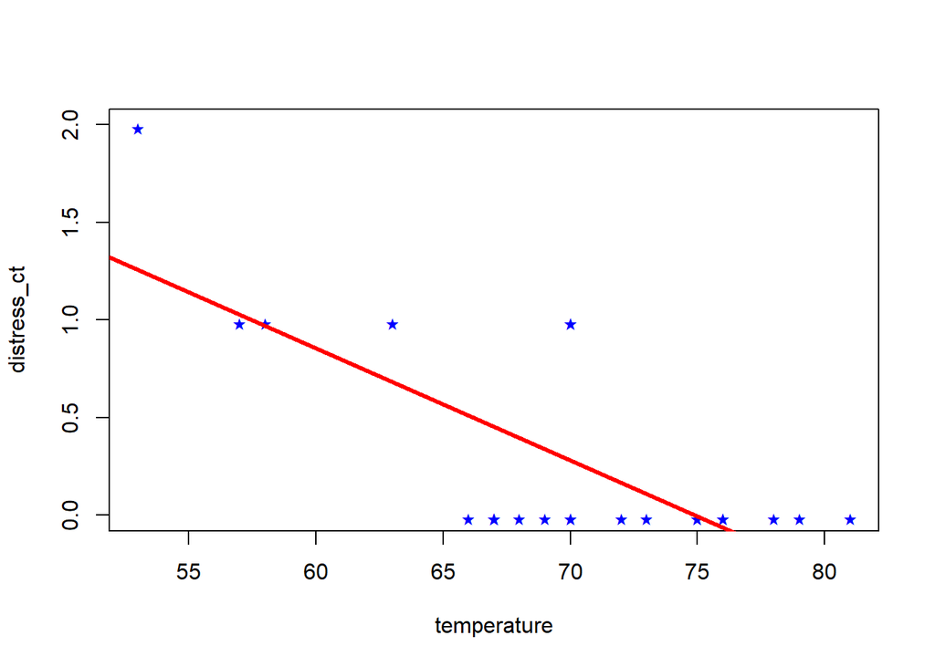

```r
plot(distress_ct ~ temperature, data = launch, pch = "★", col = "blue", bg = "red")

library(stats)
model2 <- lm(distress_ct ~ temperature)

abline(model2, col = "red", lwd = 3)
```

```r
regression_func <- function() {
  library(stats)
  # 1. 데이터를 R로 로드한다.
  data<-file.choose()

  table1 <- read.csv(data, header = T)

  col1 <- menu(colnames(table1), title = "독립변수가 될 컬럼 이름을 입력하세요 ")
  col1
  col2 <- menu(colnames(table1), title = "종속변수가 될 컬럼 이름을 입력하세요 ")

  col1 <- colnames(table1)[col1]
  col1
  col2 <- colnames(table1)[col2]
  # 2. 데이터를 가지고 plot 그래프를 그린다.

  # 3. 데이터에 맞는 회귀모델을 만든다.
  attach(table1)
              # y 축 ~ x 축
  model <- lm(as.formula(paste(col2,"~",col1)))

  plot(as.formula(paste(col2,"~",col1)), data = table1, col = "Hot Pink", bg = "red",
       main = paste("y =", round(model$coefficients[2],3),"x +",round(model$coefficients[1],3)))
  abline(model, col = "blue", lwd = 3)
}
```

#### 자동화 스크립트 생성

```r
my_r_func <- function() {


  y <- " ######################################################### \n # 1. 막대그래프              11. Decision Tree 머신러닝 \n # 2. 원형그래프              12. 규칙기반 oneR/Jriper        \n # 3. 산포도 그래프            13. 단순 회귀        \n # 4. 워드 클라우드                          \n # 5. 사분위수 그래프                                    \n # 6. 분산과 표준편차                                    \n # 7. 정규분포와 히스토그램                              \n # 8. 산포도와 회귀직선                                  \n # 9. knn 머신러닝                                       \n # 10. naive bayes 머신러닝                              \n ######################################################### "
   cat(y)
  }


my_r_func()
```

```
##  #########################################################
##  # 1. 막대그래프              11. Decision Tree 머신러닝
##  # 2. 원형그래프              12. 규칙기반 oneR/Jriper
##  # 3. 산포도 그래프            13. 단순 회귀
##  # 4. 워드 클라우드
##  # 5. 사분위수 그래프
##  # 6. 분산과 표준편차
##  # 7. 정규분포와 히스토그램
##  # 8. 산포도와 회귀직선
##  # 9. knn 머신러닝
##  # 10. naive bayes 머신러닝
##  #########################################################
```

#### 머신러닝 자동화 스크립트

```r
my_r_func <- function() {
  rm()
 y <- " ######################################################### \n # 1. 막대그래프              11. Decision Tree 머신러닝 \n # 2. 원형그래프              12. 규칙기반 oneR/Jriper        \n # 3. 산포도 그래프          13. 단순 회귀        \n # 4. 워드 클라우드                          \n # 5. 사분위수 그래프                                    \n # 6. 분산과 표준편차                                    \n # 7. 정규분포와 히스토그램                              \n # 8. 산포도와 회귀직선                                  \n # 9. knn 머신러닝                                       \n # 10. naive bayes 머신러닝                              \n ######################################################### "
   cat(y)

    ########### 1. 패키지 설치
# 현재 컴퓨터에 필요한 패키지 설치
# 만약 패키지가 존재하지 않는 경우에만 설치

  packages <- c("XML","stringr","rJava","KoNLP","wordcloud","lubridate","data.table","e1071","plyr","outliers","FSelector","gmodels","fBasics","fBasics","class","rpart","stats","RWeka")

  if (length(setdiff(packages, rownames(installed.packages()))) > 0) {
    install.packages(setdiff(packages, rownames(installed.packages())))
  }

  library(data.table)
  # x3 <- menu( c("막대그래프", "원형그래프", "산포도 그래프", "워드 클라우드", "사분위수 그래프", "분산과 표준편차","정규분포와 히스토그램","산포도와 회귀직선"
  #               "knn 머신러닝", "naive bayes 머신러닝","Decision Tree 머신러닝","규칙기반 oneR/Jriper","단순 회귀") ,
  #             title ='원하는 그래프를 선택하세요 ', graphics=T)
  x3 <- as.numeric(readline(prompt = "원하는 그래프를 선택하세요"))
  switch(x3,
        barchart={
          table <- get(readline(prompt = "테이블을 입력하세요~ "))
          x  <- menu( colnames(table) , title ='sum할 컬럼명(number)을 입력하세요 ')
          x1 <- menu( colnames(table) , title ='기준이될 컬럼명을 입력하세요 ')
          x2 <- menu( colnames(table) , title ='그루핑할 컬럼을 입력하세요 ')
          y <- tapply(table[, x], list(table[,x2], table[,x1]), sum)
          y[is.na(y)] <- 0

          barplot(y, col = rainbow(length(y)), beside = T)
          legend("topright", fill = rainbow(14), legend = rownames(y))

        },
        piechart={
          table <- get(readline(prompt = "테이블을 입력하세요~ "))
          x  <- menu( colnames(table) , title ='sum할 컬럼명(number)을 입력하세요 ')
          x1 <- menu( colnames(table) , title ='기준이될 컬럼명을 입력하세요 ')

          z <- tapply(table[,x], table[,x1], sum)

          rate <- round( z / sum(table[,x]) * 100, 1)
          pie(z, col= rainbow(length(names(z))), main = "Salary Pie Chart",
              labels = paste(names(z), rate,'%'))

        },
        plot = {
          table <- get(readline(prompt = "테이블을 입력하세요~ "))
          x1 <- menu(colnames(table) , title ='x축이될 컬럼명을 입력하세요 ')
          x2 <- menu(colnames(table) , title ='y축이될 컬럼명을 입력하세요 ')

          plot(table[,x1], table[,x2], xlab = colnames(table[x1]),
                     ylab = colnames(table[x2]), pch = '★', col ='Violet')
        },
        wordcloud = {
          data <- file.choose()
          file <- readLines(data)

          library(KoNLP)
          library(wordcloud)
          library(plyr)

          useSejongDic()
          nouns <- sapply(file, extractNoun, USE.NAMES = F)

          nouns <- unlist(nouns)
          # data 형식을 vector로 바꿈

          nouns <- nouns[nchar(nouns)>= 2]

          cnouns <- count(nouns)

          pal <- brewer.pal(6,"Dark2")

          pal <- pal[-(1)]

          x11()

          wordcloud(words=cnouns$x, freq=cnouns$freq, colors=pal, min.freq=5,
                    random.order=F)
        },
        boxplot = {
          table <- get(readline(prompt = "테이블명을 입력하세요~ "))
          x  <- menu( colnames(table) , title ='컬럼명을 입력하세요 ')

          boxplot(table[,x], horizontal = T)
        },
        var = {
            table <- get(readline(prompt = "분산을 시각화할 테이블명을 입력하시오 "))
            col <- menu(colnames(table), title = '분산을 시각화할 컬럼을 선택하세요.')
            x <- table[,col]
            cnt <- length(x)
            plot( x, main = paste("분산 =", round(var(x),3), "표준편차 =", round(sd(x),3)),
                  col = "Navy Blue",ylab = colnames(table[col]))
            lines(rep(mean(x),cnt), type = "l", col = "Violet Red")
        },
        hist = {
          table <- get(readline(prompt = "정규분포 곡선을 그릴 테이블 명을 입력하세요 "))
          col <- menu(colnames(table), title = "정규분포곡선을 그릴 컬럼명을 입력하세요 ")

          col <- table[order(table[col], decreasing = F), col]

          hist(col, col = topo.colors(8, alpha=0.7),ann = FALSE)
          par(new = T)
          plot(col, dnorm(col, mean = mean(col), sd = sd(col)), type = "l",
               main = paste(round(skewness(col),3),"정규분포 그래프"),ylab = "도수",
               axes = FALSE)
        },
        plot2 = {
          table_name <- readline(prompt = "산포도 그래프를 그릴 테이블 명을 입력하세요 ")
          table <- get(table_name)
          x_axis <- menu(colnames(table), title = "x 축 데이터를 입력하세요 ")
          y_axis <- menu(colnames(table), title = "y 축 데이터를 입력하세요 ")

          plot(table[,x_axis], table[,y_axis], main = paste(table_name, "산포도그래프"),
                xlab = colnames(table[x_axis]), ylab = colnames(table[y_axis]))
          model<- lm(table[,y_axis]~table[,x_axis])
          abline(model,col='red')
        },
        knn = {

          setwd("C:/data")
          #
          # data <- readline("분석할 csv파일명을 입력하세요 ")
          #
          print("분석할 csv파일명을 입력하세요")
          data<-file.choose()

          table1 <- na.omit(read.csv(data, stringsAsFactors = FALSE))

          col <- menu(colnames(table1), title = "라벨이 될 컬럼 이름을 입력하세요 ")

          col_n <- menu(colnames(table1), title = "제거할 컬럼 이름을 입력하세요 ")

          # colname으로 받아야함
          col1 <- colnames(table1)[col]

          normalize <- function(x) {
            return( (x-min(x))/ ( max(x)-min(x)))
          }

          # 불필요한 컬럼 삭제하기
          table1 <- table1[-col_n]

          # which : column이 위치한 숫자가 출력
          ncol <- which(colnames(table1) == col1)

          # 정규화
          table_n <- as.data.frame(lapply(table1[, -ncol],normalize))

          # z_score 표준화로 대체 사용가능
          # table_z <- as.data.frame(scale(table1[-ncol]))

          # training data 와 test data 바꾸기
          mm<-round(nrow(table_n) * 9/10)
```

```r
          table_train <- table_n[1:mm, ]
          table_test  <- table_n[(mm+1):nrow(table_n), ]

          table_train_label <- table1[1:mm, col1]
          table_test_label  <- table1[(mm+1):nrow(table_n), col1]


          # k 값 자동 생성

          library(caret)

          library(e1071)

          repeats = 20

          numbers = 10

          tunel = 10

          # "데이터가 부정확, 불완전 또는 불합리한가 어떤가를 확인하기 위해서 사용되는 처리"
          set.seed(1234)
          x = trainControl(method = "repeatedcv",

                           number = numbers,

                           repeats = repeats,

                           classProbs = TRUE,

                           summaryFunction = twoClassSummary)


          # normalize에서 label이 사라짐 -> cbind로 묶음

          model1 <- train(label~. , data = cbind(label = table_train_label, table_train), method = "knn",

                         preProcess = c("center","scale"),

                         trControl = x,

                         metric = "ROC",

                         tuneLength = tunel)



          # Summary of model
          k_n <- max(model1$bestTune)


          # knn 알고리즘
          library(class)

          result1 <- knn(train=table_train, test=table_test, cl= table_train_label, k = k_n )

          # 확률구하기
          prop.table( table(ifelse(table1[(mm+1):nrow(table_n), col1]==result1,"o","x" )))

          # 이원교차표
          library(gmodels)

          CrossTable( x= table_test_label, y= result1, prop.chisq=FALSE)



          # 예측할 환자정보
          print("예측할 환자정보를 입력하세요.")
          patient <- file.choose()
          table2 <- na.omit(read.csv(patient))


          # rbind 해서 normalize하면 안됨. 트레이닝은 전체 테이터로만 해야 함.
          col2 <- colnames(table2)[col]

          table2 <- table2[-col_n]

          # print(table2)
          ncol <- which(colnames(table2) == col2)
          table_test2 <- table2[,-ncol]
          table_test2 <- normalize(table_test2)

          # print(table_test2)

          result2 <- knn(train=table_train, test = table_test2, cl= table_train_label, k = k_n )

          return(paste(result2,"(으)로 예측됩니다"))
        },
        naive_bayes = {

          setwd("C:/data")

          print("분석할 csv파일명을 입력하세요 ")
          data<-file.choose()

          na.string <- NA

          table1 <- read.csv(data, stringsAsFactors = F, header = F, na.string = na.string)

          col <- menu(colnames(table1), title = "라벨이 될 컬럼 이름을 입력하세요 ")

          col1 <- menu(colnames(table1), title = "수정할 컬럼 이름을 입력하세요 ")

          ch1 <- readline(prompt = "제거할 문자를 입력하세요 ")

          lap <- readline(prompt = "laplace값을 입력하세요 ")

          # data 정제

          table1[which(table1[,col1] == ch1), nrow(table)] <- NA

          # 3. factor로 변환한다.

          for (i in 1:dim(table1)[2]) {
            table1[,i] <- factor(table1[,i])
          }

          # 4. 훈련데이터와 테스트 데이터로 나눈다.

          set.seed(1)

          # 행의 건수 확인
          train_cnt <- round(0.75 * dim(table1)[1])
          # shuffle 하는 방법 중 하나
          train_indx <- sample(1:dim(table1)[1], train_cnt, replace = F)

          table_train <- table1[train_indx,]
          table_test <- table1[-train_indx,]

          # 5. 나이브 베이즈 함수를 이용해서 독버섯과 일반 버섯을 분류하는 모델을 생성한다.

          library(e1071)
          # V1~: label(기준으로 사용), laplace: positive double controlling Laplace smoothing.
          # laplace로 공격적으로 필터링하는 정도를 조절할 수 있음
          model1 <- naiveBayes(table_train[,col]~. , data = table_train, laplace = as.numeric(lap))

          # 생성된 분류모델
          model1

          # 6. 모델로 테스트 데이터로 정확도 측성한다.
          # 예측하기
          result1 <- predict(model1, table_test[, -col])
          # head(result1)

          # 7. 이원 교차표로 분류의 최종 결과를 확인한다.
          library(gmodels)

          CrossTable(x = table_test[,col], y = result1)
                      # 실제              예측
        },
        Decision_Tree = {

          print("분석할 csv파일을 입력하세요 ")
          data <- file.choose()
          na.string <- NA
          # 연속형데이터는 factor로 변환하면....안돼
          table1 <- read.csv(data, header = T, na.string = na.string)

          d_col <- menu(c(colnames(table1),'non'), title="삭제할 컬럼을 선택하시오 ")

          table1 <- table1[,-d_col]

          l_col <- menu(colnames(table1), title="label이 될 컬럼을 선택하시오 ")
          trials <- readline(prompt = "trials 값을 입력하세요 ")

          # 분석 쿼리
          library(C50)
          library(gmodels)
          library(rpart)
          library(rattle)


          # 조절할 것1_set.seed()
          set.seed(11)
          table_shuffle <- table1[sample(nrow(table1)),]


          train_num <- round(0.7*nrow(table_shuffle),0)
          table_train <- table_shuffle[1:train_num, ]
          table_test <- table_shuffle[(train_num +1): nrow(table_shuffle), ]

          l_col <-  colnames(table1)[l_col]
          ncol1 <- which(colnames(table1) == l_col)

          # 조절할 것2_trials:laplace와 비슷
          model <- C5.0(table_train[ ,-ncol1], table_train[ ,ncol1], trials = as.numeric(trials))
          result <- predict(model, table_test[ ,-ncol1])

          CrossTable(x = table_test[,ncol1], y= result)

          # as.formula와 paste로 ~.을 붙여야한다.
          tree <- rpart(label~. , data=data.frame(table1[,-ncol1], label = table1[,l_col]),
                        control=rpart.control(minsplit=2))
          fancyRpartPlot(tree,palettes = c("Greys","RdPu"))
        },
        rule_based = {
          library(RWeka)
          library(gmodels)

          rm()
          setwd("C:/data")
          x3 <- menu( c("OneR","JRip") ,
                      title ='원하는 그래프를 선택하세요 ')

           print("분석할 csv파일명을 입력하세요 ")
          data<-file.choose()

          table1 <- read.csv(data, header = T)

          col <- menu(colnames(table1), title = "라벨이 될 컬럼 이름을 입력하세요 ")

          col1 <- colnames(table1)[col]


          set.seed(1)

          # 행의 건수 확인
          train_cnt <- round(0.75 * dim(table1)[1])
          # shuffle 하는 방법 중 하나
          train_indx <- sample(1:dim(table1)[1], train_cnt, replace = F)

          table_train <- table1[train_indx,]
          table_test <- table1[-train_indx,]
```

```r
          library(RWeka)

          switch(x3,
                 OneR = {
                                  # formula : 함수식
                   model1 <- OneR(as.formula(paste(col1,"~.")) , data = table_train)
                 },
                 JRip = {
                   model1 <- JRip(as.formula(paste(col1,"~.")), data = table_train)
                 }
                 )


          # 예측하기
          result1 <- predict(model1, table_test[, -col])

          # 이원 교차표로 분류의 최종 결과를 확인한다.

          CrossTable(x = table_test[,col], y = result1)
        },
        linear_regression ={
          library(stats)
          # 1. 데이터를 R로 로드한다.
          data<-file.choose()

          table1 <- read.csv(data, header = T)

          col1 <- menu(colnames(table1), title = "독립변수가 될 컬럼 이름을 입력하세요 ")
          col1
          col2 <- menu(colnames(table1), title = "종속변수가 될 컬럼 이름을 입력하세요 ")

          col1 <- colnames(table1)[col1]
          col1
          col2 <- colnames(table1)[col2]
          # 2. 데이터를 가지고 plot 그래프를 그린다.

          # 3. 데이터에 맞는 회귀모델을 만든다.
          attach(table1)
                      # y 축 ~ x 축
          model <- lm(as.formula(paste(col2,"~",col1)))

          plot(as.formula(paste(col2,"~",col1)), data = table1, col = "Hot Pink", bg = "red",
               main = paste("y =", round(model$coefficients[2],3),"x +",round(model$coefficients[1],3)))
          abline(model, col = "blue", lwd = 3)
        }

  )

}

# my_r_func()
```

### 실습3.

data: 코스피 지수 수익률과 삼성, 현대 자동차 주식 수익률 독립변수: 코스피지수 종속변수: 삼성 주식 수익률

```r
# 1. 데이터를 내려받는다
# K_index.csv 코스피 지수
# S_stock.csv 삼성 수익률
# H_stock.csv 현대 자동차 수익률

k_index <- read.csv("C:/data/K_index.csv", header = T, stringsAsFactors = F)
s_stock <- read.csv("C:/data/S_stock.csv", header = T, stringsAsFactors = F)
h_stock <- read.csv("C:/data/H_stock.csv", header = T, stringsAsFactors = F)

# 2. 위의 세 데이터를 merge한다
all_data <- merge(merge(k_index,s_stock),h_stock)
head(all_data)
```

```
##         date   kospi k_rate s_price s_rate h_price h_rate
## 1 2015-03-25 2042.81     NA 1485000     NA   45500     NA
## 2 2015-03-26 2022.56 -0.991 1421000 -4.310   45900  0.879
## 3 2015-03-27 2019.80 -0.136 1421000  0.000   45000 -1.961
## 4 2015-03-30 2030.04  0.507 1428000  0.493   45600  1.333
## 5 2015-03-31 2041.03  0.541 1441000  0.910   46000  0.877
## 6 2015-04-01 2028.45 -0.616 1423000 -1.249   45950 -0.109
```

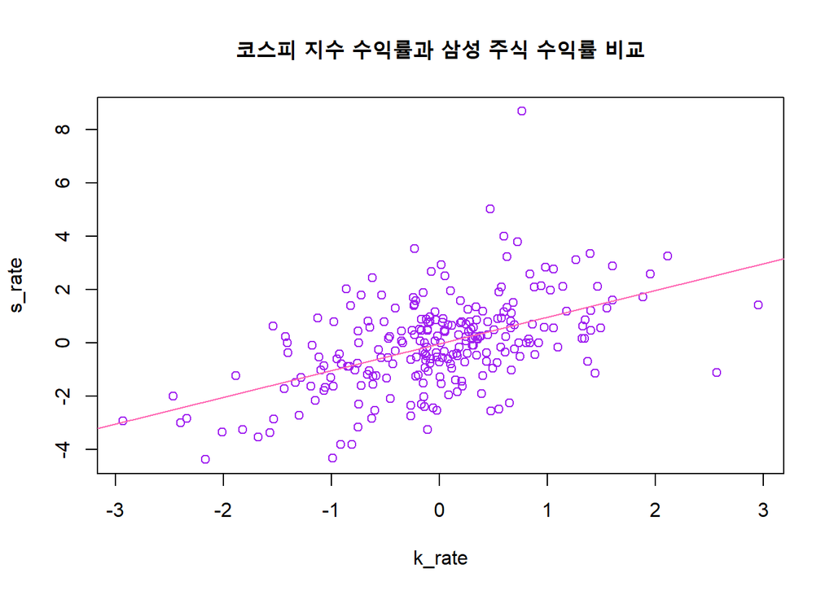

```r
# 3. x축을 코스피지수로, y축은 삼성 수익률로 해서 plot 그래프를 그린다
attach(all_data)
plot(k_rate, s_rate, col = "Purple", main = "코스피 지수 수익률과 삼성 주식 수익률 비교")

# 4. 회귀함수를 이용해서 회귀직선을 그린다.
library(stats)
              # 종속변수, 독립변수, dataframe
model_s <- lm(s_rate ~ k_rate, data = all_data)
abline(model_s, col = "Hot Pink")
```

```r
# 기울기: 1.001
```

> 설명: 회귀 모수 중 기울기 1보다 크면 공격적 주식이고 1보다 방어적 주식이다. 기울기가 낮을 수록 뚝심이 강해서 시장과 상관없이 움직이는 것이고 기울기가 높을 수록 탄력적으로 움직이는 것인데 수익률이 다소 낮더라도 안전하게 벌고 싶다면 기울기 낮은 것을 선택해야 한다. 위험성이 높아서 수익률이 높은 것을 공격적으로 노린다면 기울기가 높은 것을 선택해야한다.

#### 현대자동차의 회귀 직선 그래프와 회귀식을 구하시오

```r
write.csv(all_data,file = "C:/data/all_data.csv")
# my_r_func()
# 기울기:  0.635
```

[output not shown]

### 상관관계

##### 상관분석은 두 변수가 서로 어떠한 관계인지 파악하는 분석으로 기울기에 따라 양의 상관관계, 음의 상관관계로 나눌 수 있다.

##### 점들의 흩어져있는 모습을 보고 두 변수의 관계를 파악하는데 밀도의 차이에 따라서 상관계수를 나타낸다 ##### 상관계수의 기호는 “r”을 사용하낟. ##### 상관계수의 수치가 0에 가까울수록 상관관계가 약하다는 뜻이고  
+1에 가까우면 양의 상관관계가 강하고 -1에 가까우면 음의 상관관계가 강하다.

#### 예. 온도와 0형 링 파손수 두 변수간의 상관관계가 강한지 약한지 알아내시오

```r
launch <- read.csv("C:/data/challenger.csv", header = T)

attach(launch)
cor(temperature, distress_ct)
```

```
## [1] -0.725671
```

> 음의 상관관계가 높게 나타나고 있다.

#### 문제283. 코스피 지수 수익율과 삼성전자의 수익율의 상관관계를 구하시오

```r
attach(all_data)
cor(na.omit(k_rate), na.omit(s_rate))
```

```
## [1] 0.5142455
```

```r
cor(na.omit(k_rate), na.omit(h_rate))
```

```
## [1] 0.3262777
```

> 설명: 상관계수는 시장과 얼마나 비슷하게 움직이느냐를 찾는 것이다.  
> 현업에서 0.65 ~ 0.7 보다 큰 것부터 가치가 있다고 판단하고 투자 분석을 한다.

### 3. 다중 선형 회귀 분석 이론

“독립변수가 여러개인 경우의 회귀분석”  
단순선형 회귀 분석의 목적이 하나의 독립변수만 가지고 종속변수를 예측하기 위한 회귀모형을 만들기 위한 것이었다면  
독립변수(x)들을 가지고 종속변수(y)를 예측하기 위한 회귀모형을 만드는 것이다.  
예. 집값을 종속변수라고 보면 집값에 영향을 미치는 요소가 단순히 평수(독립변수)만 있는 것이 아니다.  
집값(종속변수) <- 평수, 교통, 학군, 범죄율, …

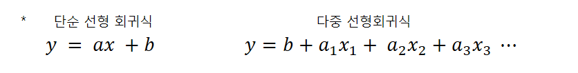

회귀식